# Data Insight and Visualization Report

# Insights and Visualization from Wrangled Twitter Master dataset

# January, 2023

### Introduction

The wrangled master dataset created from the data wrangling phase were visualized for the following insights:

- Performance of the classifier for various dog class
- Correlation between favorite and retweet counts.
- The rate of change of the favorite and retweet counts within the period WeRateDogs Twitter archive data was collected

### 1. Performance of the classifier for various dog class

### First, we perform descriptive statistics on the wrangled dataset : "twitter_master_df"

twitter_master_df.describe()

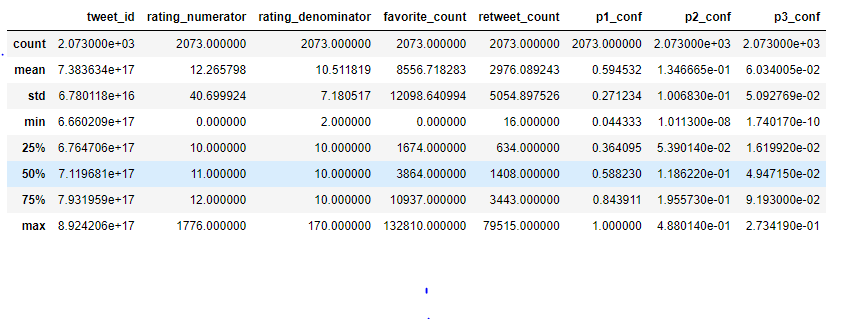

### Next, we visualize at the top 15 dog ratings and breeds of the first image predicted by the algorithm

[figure not shown]

[figure not shown]

### Next, we investigate the dog class with the maximum number of retweet counts, favorite counts and the highest confidence level (P1) revealed by our descriptive statistics

```python
#highest retweet counts
twitter_master_df[twitter_master_df.retweet_count == 79515.0]
#highest retweet counts
twitter_master_df[twitter_master_df.favorite_count == 132810.0]
# highest p1_conf
twitter_master_df[twitter_master_df.p1_conf == 1.0]
```

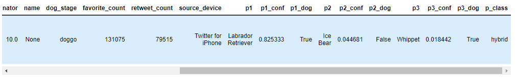

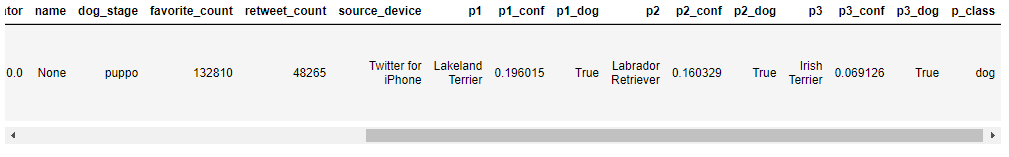

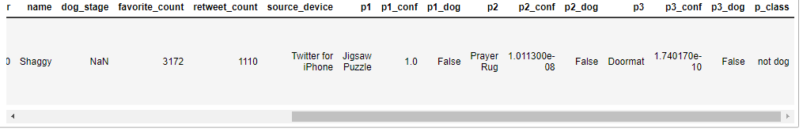

### 2. Correlation between favorite and retweet counts.

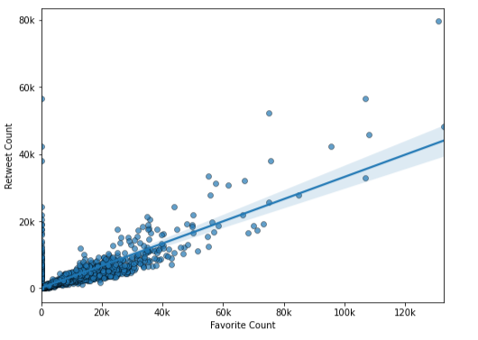

### From the figure above , It is obvious that there is a positive correlation between favorite counts and retweet counts. The counts is highly concentrated between 0 to 40k favorite counts, with more counts lying below the regression line.

### 3. The rate of change of the favorite and retweet counts within the period WeRateDogs Twitter archive data was collected

### From the figure below, it is observed that the intensities of both favorite and retweet counts were similar between 2015-11 to 2016-05, though the number of favorite counts were higher than retweet counts. The favourite count showed a steady increasing trend above the retweet counts from around 2016-09 to slightly above 2017-07. The majority of the retweet counts however remained between 0 and 20k.

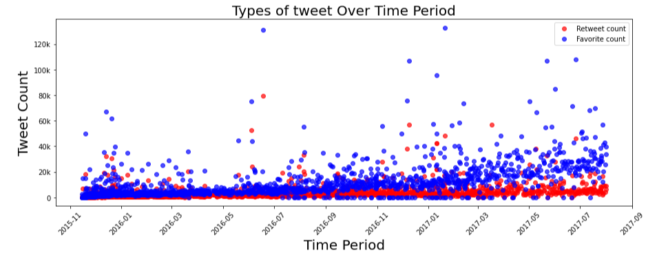